# Spatiotemporal Analysis of Traffic and PM 2.5 levels in Delhi (2006–2018)

Shubham Love

Fall 2025

## Portfolio Map 8: New Tool

The idea behind this project is to plot a map of the PM 2.5 data collected in Delhi across its air quality monitoring stations between 2006-2018 and perform statistical analysis on the same to derive insights using R. The key questions that this analysis intends to answer are:

- 1. Does traffic time matter specifically at choke points?
- 2. Are choke point stations generally more polluted than others?
- 3. Is the difference between Peak and Off-Peak significantly larger at choke points compared to control stations?

To do this, air quality monitoring stations across Delhi are plotted alongside a shortlisted set of traffic choke points in Delhi. The PM 2.5 monitoring stations near (within a 2 km radius) these choke points are identified and compared against the rest of the dataset using a linear model regression.

Loading required packages for the project:

```r
library(tidyverse)
library(sf)
library(tidygeocoder)
library(units)
library(osmdata)
```

### Data Collection and Geocoding of Traffic Choke Points

To identify areas of significant traffic congestion, local and national newspaper articles and traffic reports were surveyed, compiling a list of 48 persistent “choke points” across Delhi.

These locations were geocoded into spatial coordinates using the `tidygeocoder` R package. This package utilizes the OpenStreetMap (Nominatim) API, which provides a free, open-source geocoding service (subject to usage limits). The code below was used for the batch geocoding process used to generate the spatial dataset geocoded_delhi_chokepoints.csv.

```r
# List of 48 Choke Points identified via media survey
choke_points <- tribble(
  ~choke_id, ~name,"CP01", "Yusuf Sarai Market, Safdarjung Hospital, Delhi","CP02", "Rangpuri Roundabout, under NH-48 Flyover, Delhi","CP03", "Andheria Mor, MG Road, Delhi","CP04", "CDR Chowk, Mehrauli-Gurugram Road, Delhi","CP05", "Under Chirag Delhi Flyover, Delhi","CP06", "Savitri Flyover, Outer Ring Road, Delhi","CP07", "Tara Apartments, Alaknanda Road, Delhi","CP08", "Mathura Road, Madanpur Khadar, Delhi","CP09", "Crowne Plaza, Maa Anandmayee Marg, Okhla, Delhi","CP10", "Shaheed Bijender Singh Gurjar Marg, Jaitpur, Delhi","CP11", "Sarai Kale Khan, Delhi","CP12", "Saket Metro Station, Delhi","CP13", "Khanpur T-Point, Delhi","CP14", "Hamdard T-Point, Delhi","CP15", "Pul Prahladpur to Lal Kuan Traffic Signal, MB Road, Delhi","CP16", "Netaji Subhash Marg, Delhi Gate to Nukkad Faiz Bazar, Delhi","CP17", "New Delhi Railway Station, Paharganj Side","CP18", "New Delhi Railway Station, Ajmeri Gate Side","CP19", "Rani Jhansi Road, Delhi","CP20", "Anand Parbat, Delhi","CP21", "Majnu ka Tila, Delhi","CP22", "Tis Hazari Court, Delhi","CP23", "Red Fort, Netaji Subhash Marg, Delhi","CP24", "Road No. 62, Seemapuri Roundabout, Delhi","CP25", "Nirman Vihar, Vikas Marg, Delhi","CP26", "Laxmi Nagar, Vikas Marg, Delhi","CP27", "ISBT Anand Vihar Road, Delhi","CP28", "Sardar Patel Marg, Delhi","CP29", "Teen Murti Marg to GKP, Chanakyapuri, Delhi","CP30", "Purana Quila Road, India Gate, Delhi","CP31", "Tughlaq Road Roundabout, Delhi","CP32", "Bhinder Point, Delhi","CP33", "Punjabi Bagh to Raja Garden Flyover, Delhi","CP34", "Janakpuri District Centre to Uttam Nagar Chowk, Delhi","CP35", "Najafgarh Road, Delhi","CP36", "Uttam Nagar Terminal to Nawada Metro Station, Delhi","CP37", "Road No. 201, Dwarka Sector-1, Rudra Cut to Palam Flyover, Delhi","CP38", "Mayapuri Chowk to Kirti Nagar Metro Station, Delhi","CP39", "Banda Bahadur (Barapullah) Bairangi Marg Flyover, Delhi","CP40", "Sarita Vihar Flyover, Delhi","CP41", "Geeta Colony Flyover, Delhi","CP42", "Azadpur Chowk Flyover, Delhi","CP43", "Punjabi Bagh Flyover, Delhi","CP44", "Mukarba Chowk Flyover, Delhi","CP45", "Hanuman Setu Flyover, Delhi","CP46", "Rani Jhansi Flyover, Delhi", "CP47", "Palam Dwarka Flyover, Delhi","CP48","Peeragarhi Flyover, Delhi")

# Geocoding via OpenStreetMap

# choke_geo <- choke_points %>%
#   geocode(address = name, method  = "osm",lat     = latitude,long    = longitude,full_results = FALSE)

# Clean for NA and save the results
# choke_geo_clean <- choke_geo %>%
#   filter(!is.na(latitude) & !is.na(longitude))

# write_csv(choke_geo_clean, "geocoded_delhi_chokepoints.csv")
```

### Main setup:

```r
# Loading Data
stations_raw <- read_csv("delhi_pm25_2018_stations_latlon.csv")
```

```r
traffic_cp   <- read_csv("geocoded_delhi_chokepoints.csv") # Only 19 of the total were geocoded to the map.
# Converting to SF (Simple Features) objects
stations_sf <- st_as_sf(stations_raw, coords = c("longitude", "latitude"), crs = 4326) # WGS 84
choke_sf    <- st_as_sf(traffic_cp, coords = c("longitude", "latitude"), crs = 4326) # WGS 84

# Getting Delhi boundary from OpenStreetMap
bb_delhi <- getbb("Delhi, India")
delhi_boundary_raw <- opq(bb_delhi) %>%
  add_osm_feature(key = "admin_level", value = "4") %>%
  add_osm_feature(key = "name", value = "Delhi") %>%
  osmdata_sf()

delhi_boundary <- delhi_boundary_raw$osm_multipolygons

delhi_boundary <- st_union(delhi_boundary) %>% st_as_sf() # Dissolve points into a single polygon

target_crs <- 32643  # UTM zone 43N (Delhi) to ensure accuracy in measuring distances | https://epsg.io/32643

stations_utm       <- st_transform(stations_sf, target_crs)
choke_utm          <- st_transform(choke_sf, target_crs)
delhi_boundary_utm <- st_transform(delhi_boundary, target_crs)
```

### Proximity Analysis:

```r
dist_threshold <- set_units(2, "km") #Distance threshold was chosen as 2 km as a reasonable estimate

# Identify which stations are within 2km of any choke point
# st_is_within_distance returns a sparse list. lengths > 0 means a match exists.
is_near_choke_index <- st_is_within_distance(stations_utm, choke_utm, dist = dist_threshold)
stations_utm$near_choke <- lengths(is_near_choke_index) > 0

# Create a clean classification df
station_class_df <- stations_utm %>%
  st_drop_geometry() %>%
  select(station, near_choke) %>%
  mutate(location_type = if_else(near_choke, "Near Choke Point", "Control Station"))

# Check counts
print(table(station_class_df$location_type))
```

```
##
##  Control Station Near Choke Point
##               26                9
```

### Visualization

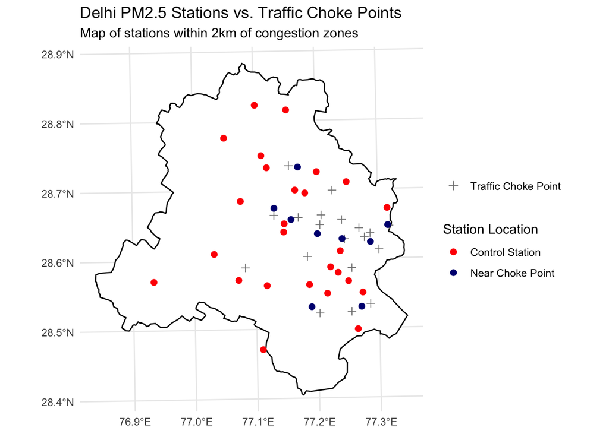

```r
main_plot<- ggplot() +
  # Delhi Boundary
  geom_sf(data = delhi_boundary_utm, fill = "white", color = "black", linewidth = 0.5) +

  # Choke Points
  geom_sf(data = choke_utm, aes(shape = "Traffic Choke Point"), color = "grey50", size = 2) +

  # Plotting PM 2.5 Monitoring Stations
  geom_sf(data = stations_utm, aes(color = near_choke), size = 2) +
  scale_color_manual(
    values = c("TRUE" = "navy", "FALSE" = "red"),
    labels = c("TRUE" = "Near Choke Point", "FALSE" = "Control Station")) +

  scale_shape_manual(name = NULL, values = c("Traffic Choke Point" = 3)) +
  # Labels and Theme
  labs(
    title = "Delhi PM2.5 Stations vs. Traffic Choke Points",
    subtitle = "Map of stations within 2km of congestion zones",
    color = "Station Location" # Legend Title
  ) +
  theme_minimal()

print(main_plot)
```

### Statistical Analysis

**Setup:**

```r
library(jtools) # for formatted regression results
pm <- read_csv("delhi_hourly_pm25_2006-2018.csv") # Sourced from doi: 10.17632/snp7sbkb36.2
pm_analysis <- pm %>%
  inner_join(station_class_df, by = "station") %>%
  filter(!is.na(value)) # Remove missing PM2.5 readings

pm_analysis <- pm_analysis %>%
  mutate(
    tod_period = case_when(
      hour >= 8  & hour < 11 ~ "Morning_Peak",
      hour >= 17 & hour < 21 ~ "Evening_Peak",
      hour >= 13 & hour < 14 ~ "Lunch",
      TRUE                   ~ "Off_Peak"),
    tod_period = factor(tod_period, levels = c("Off_Peak", "Morning_Peak", "Lunch", "Evening_Peak")),
    location_type = factor(location_type, levels = c("Control Station", "Near Choke Point")))
```

**1. Does traffic time matter specifically at choke points?**

```r
choke_stn<- filter(pm_analysis, location_type == "Near Choke Point")
model1 <- lm(value ~ tod_period, data = choke_stn)
summ(model1)
```

```
## MODEL INFO:
## Observations: 915869
## Dependent Variable: value
## Type: OLS linear regression
##
## MODEL FIT:
## F(3,915865) = 24.18, p = 0.00
## R² = 0.00
## Adj. R² = 0.00
##
## Standard errors:OLS
## ------------------------------------------------------------
##                                  Est.   S.E.   t val.      p
## ---------------------------- -------- ------ -------- ------
## (Intercept)                    182.59   2.31    79.01   0.00
## tod_periodMorning_Peak           8.90   5.85     1.52   0.13
## tod_periodLunch                -15.14   9.53    -1.59   0.11
## tod_periodEvening_Peak         -40.79   5.15    -7.92   0.00
## ------------------------------------------------------------
```

**Discussion:** It can be observed through the results that at choke points only during the Evening Peak a significant decline in PM 2.5 levels is observed. This may not be attributed to traffic, but to other meteorological factors.

**2. Are choke point stations generally more polluted than others?**

```r
model2 <- lm(value ~ location_type, data = pm_analysis)
summ(model2)
```

```
## MODEL INFO:
## Observations: 2373270
## Dependent Variable: value
## Type: OLS linear regression
##
## MODEL FIT:
## F(1,2373268) = 1268.48, p = 0.00
## R² = 0.00
## Adj. R² = 0.00
##
## Standard errors:OLS
## -----------------------------------------------------------
##                                 Est.   S.E.   t val.      p
## --------------------------- -------- ------ -------- ------
## (Intercept)                   122.49   0.94   130.79   0.00
## location_typeNear Choke        53.70   1.51    35.62   0.00
## Point
## -----------------------------------------------------------
```

**Discussion:** The choke point stations are significantly more polluted as the model indicates a statistically significant difference in pollution levels between the two location types - stations near choke points vs. stations away from choke points (p < 0.00).

**3. Is the difference between Peak and Off-Peak significantly larger at choke points compared to control stations?**

```r
model3 <- lm(value ~ tod_period * location_type, data = pm_analysis)
summ(model3)
```

```
## MODEL INFO:
## Observations: 2373270
## Dependent Variable: value
## Type: OLS linear regression
##
## MODEL FIT:
## F(7,2373262) = 246.51, p = 0.00
## R² = 0.00
## Adj. R² = 0.00
##
## Standard errors:OLS
## ----------------------------------------------------------------------------
##                                                  Est.   S.E.   t val.      p
## -------------------------------------------- -------- ------ -------- ------
## (Intercept)                                    127.21   1.15   110.86   0.00
## tod_periodMorning_Peak                          16.64   2.89     5.75   0.00
## tod_periodLunch                                -21.12   4.73    -4.46   0.00
## tod_periodEvening_Peak                         -35.15   2.56   -13.75   0.00
## location_typeNear Choke                         55.38   1.85    29.99   0.00
## Point
## tod_periodMorning_Peak:location_typeNear        -7.74   4.67    -1.66   0.10
## Choke Point
## tod_periodLunch:location_typeNear                5.98   7.61     0.79   0.43
## Choke Point
## tod_periodEvening_Peak:location_typeNear        -5.64   4.11    -1.37   0.17
## Choke Point
## ----------------------------------------------------------------------------
```

**Discussion:** Model 3 confirms that while Choke Points have significantly higher baseline pollution (+55.38), the diurnal pattern is statistically identical to Control Stations. There is no evidence that traffic peaks cause a unique or disproportionate spike in pollution at Choke Points specifically; they are simply more polluted at all times of the day.

### Final Discussion:

The analysis shows a significant correlation between spatial location and PM 2.5 levels, as stations situated within 2km of identified traffic choke points registered significantly higher baseline pollution levels (+53.7 units) compared to control stations. Contrary to the hypothesis that rush-hour traffic causes spikes in pollution, the temporal analysis showed that “Evening Peaks” actually experienced lower PM 2.5 levels than the “Off-Peak” baseline.